# Исследование объявлений о продаже квартир

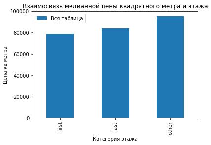

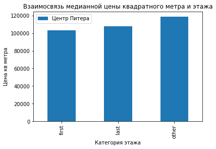

```python
# Более наглядное отображение взаимосвязи
floor_table.plot(x='floor_category', y='sqr_m_price', kind='bar', label='Вся таблица')
plt.title('Взаимосвязь медианной цены квадратного метра и этажа')
plt.xlabel('Категория этажа')
plt.ylabel('Цена кв метра');

floor_table_piter.plot(x='floor_category', y='sqr_m_price', kind='bar', label='Центр Питера')
plt.title('Взаимосвязь медианной цены квадратного метра и этажа')
plt.xlabel('Категория этажа')
plt.ylabel('Цена кв метра');
```

В целом для центра Питера сохраняется закономерность, применимая ко всей таблице - квартиры на первом и последнем этажах стоят дешевле, чем на других. Однако для центральной зоны разброс цен чуть менее существенный (во всяком случае в процентном соотношении), нежели за ее пределами.

```python
# Зависимость цены от дня недели
day_table = good_df.groupby('weekday', as_index=False)['sqr_m_price'].median()
display(day_table)
day_table_piter = piter_df.query('center_km <= 8').groupby('weekday', as_index=False)['sqr_m_price'].median()
display(day_table_piter)
```

|  | weekday | sqr_m_price |
| --- | --- | --- |
| 0 | 0 | 92156.862745 |
| 1 | 1 | 92212.806026 |
| 2 | 2 | 92429.577465 |
| 3 | 3 | 92500.000000 |
| 4 | 4 | 91836.734694 |
| 5 | 5 | 91007.430070 |
| 6 | 6 | 91531.430756 |

|  | weekday | sqr_m_price |
| --- | --- | --- |
| 0 | 0 | 116027.874564 |
| 1 | 1 | 111713.618450 |
| 2 | 2 | 112605.283471 |
| 3 | 3 | 115005.922816 |
| 4 | 4 | 112862.685171 |
| 5 | 5 | 117857.142857 |
| 6 | 6 | 116666.666667 |

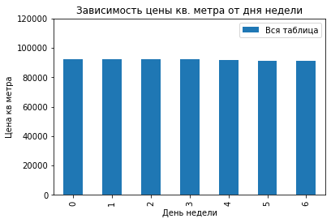

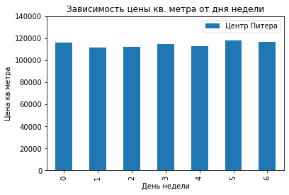

```python
# Более наглядное отображение взаимосвязи
day_table.plot(x='weekday', y='sqr_m_price', kind='bar', ylim=(0, 120000), label='Вся таблица')
plt.title('Зависимость цены кв. метра от дня недели')
plt.xlabel('День недели')
plt.ylabel('Цена кв метра');

day_table_piter.plot(x='weekday', y='sqr_m_price', kind='bar', ylim=(0, 140000), label='Центр Питера')
plt.title('Зависимость цены кв. метра от дня недели')
plt.xlabel('День недели')
plt.ylabel('Цена кв метра');
```

В обоих случаях существенной взаимосвзяи не наблюдается

```python
# Зависимость цены от месяца
month_table = good_df.groupby('month', as_index=False)['sqr_m_price'].median()
display(month_table)
month_table_piter = piter_df.query('center_km <= 8').groupby('month', as_index=False)['sqr_m_price'].median()
display(month_table_piter)
```

|  | month | sqr_m_price |
| --- | --- | --- |
| 0 | 1 | 92656.781565 |
| 1 | 2 | 92277.877162 |
| 2 | 3 | 92735.703246 |
| 3 | 4 | 91291.360294 |
| 4 | 5 | 90606.060606 |
| 5 | 6 | 90000.000000 |
| 6 | 7 | 92421.441774 |
| 7 | 8 | 94269.870610 |
| 8 | 9 | 93354.430380 |
| 9 | 10 | 91931.867496 |
| 10 | 11 | 92465.753425 |
| 11 | 12 | 90340.909091 |

|  | month | sqr_m_price |
| --- | --- | --- |
| 0 | 1 | 115765.306122 |
| 1 | 2 | 113930.693069 |
| 2 | 3 | 125912.408759 |
| 3 | 4 | 110120.481928 |
| 4 | 5 | 113247.863248 |
| 5 | 6 | 107309.755289 |
| 6 | 7 | 113089.005236 |
| 7 | 8 | 121062.500000 |
| 8 | 9 | 113333.333333 |
| 9 | 10 | 110646.391639 |
| 10 | 11 | 109958.506224 |
| 11 | 12 | 112668.045502 |

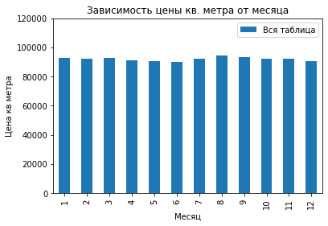

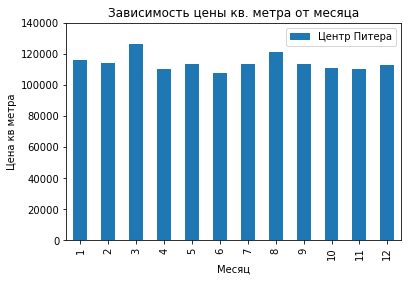

```python
# Более наглядное отображение взаимосвязи
month_table.plot(x='month', y='sqr_m_price', kind='bar', ylim=(0, 120000), label='Вся таблица')
plt.title('Зависимость цены кв. метра от месяца')
plt.xlabel('Месяц')
plt.ylabel('Цена кв метра');

month_table_piter.plot(x='month', y='sqr_m_price', kind='bar', ylim=(0, 140000), label='Центр Питера')
plt.title('Зависимость цены кв. метра от месяца')
plt.xlabel('Месяц')
plt.ylabel('Цена кв метра');
```

Центру Петербурга также как и другим районам свойственна некоторая цикличность ценообразования, однако в центральной зоне более отчетливо выделяются резкие скачки роста и падения цен - в марте, августе (резкий рост) и апреле, сентябре (резкое падение) соответственно.

```python
# Зависимость цены от года
year_table = good_df.groupby('year', as_index=False)['sqr_m_price'].median()
display(year_table)
year_table_piter = piter_df.query('center_km <= 8').groupby('year', as_index=False)['sqr_m_price'].median()
display(year_table_piter)
```

|  | year | sqr_m_price |
| --- | --- | --- |
| 0 | 2015 | 88235.294118 |
| 1 | 2016 | 89610.112696 |
| 2 | 2017 | 90000.000000 |
| 3 | 2018 | 93807.668649 |
| 4 | 2019 | 102440.476190 |

|  | year | sqr_m_price |
| --- | --- | --- |
| 0 | 2015 | 102998.062335 |
| 1 | 2016 | 109143.155695 |
| 2 | 2017 | 112000.000000 |
| 3 | 2018 | 116707.317073 |
| 4 | 2019 | 125250.836120 |

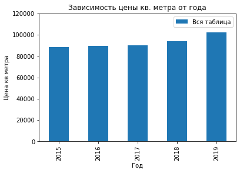

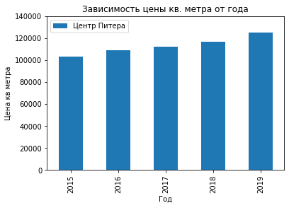

```python
# Более наглядное отображение взаимосвязи
year_table.plot(x='year', y='sqr_m_price', kind='bar', ylim=(0, 120000), label='Вся таблица')
plt.title('Зависимость цены кв. метра от года')
plt.xlabel('Год')
plt.ylabel('Цена кв метра');

year_table_piter.plot(x='year', y='sqr_m_price', kind='bar', ylim=(0, 140000), label='Центр Питера')
plt.title('Зависимость цены кв. метра от года')
plt.xlabel('Год')
plt.ylabel('Цена кв метра');
```

В обеих выборках четко прослеживается тенденция роста стоимости жилья от года к году. В этом плане инфляция сказывается на стоимости квартир в центре точно так же, как и на квартирах в других районах.